# Assignment 4

Cameron Atkins

2023-12-08

## Problem 01

1a. First start by calculating the covariance matrix (denoted as Σ). Set up the equation, but use R to calculate the matrix.

```r
df <- data.frame(x1 = c(2, 3, 5, 6, 10),
                 x2 = c(3, 4, 6, 7, 11))
cov_matrix <- matrix((cov(df)), nrow = 2, byrow=TRUE)
print(cov_matrix)
```

```
##      [,1] [,2]
## [1,]  9.7  9.7
## [2,]  9.7  9.7
```

1b. Find the eigenvalues by calculating det(Σ − λI) and solving for λ

```r
eigen_result <- eigen(cov_matrix)
eigenvalues <- eigen_result$values
eigenvectors <- eigen_result$vectors

# Print eigenvalues
print(eigenvalues)
```

```
## [1] 19.4  0.0
```

1c. Compute the eigenvectors corresponding to each eigenvalue using the properties of eigenvalues and eigenvectors: Σei = λei Where ei is the ith eigenvector. Then convert ei to a unit eigenvector using the formula: ei/||ei||

```r
#Eigenvectors
print(eigenvectors)
```

```
##           [,1]       [,2]
## [1,] 0.7071068 -0.7071068
## [2,] 0.7071068  0.7071068
```

```r
# Normalize and print each eigenvector
normalized_eigenvectors <- eigenvectors / sqrt(rowSums(eigenvectors^2))
print(normalized_eigenvectors)
```

```
##           [,1]       [,2]
## [1,] 0.7071068 -0.7071068
## [2,] 0.7071068  0.7071068
```

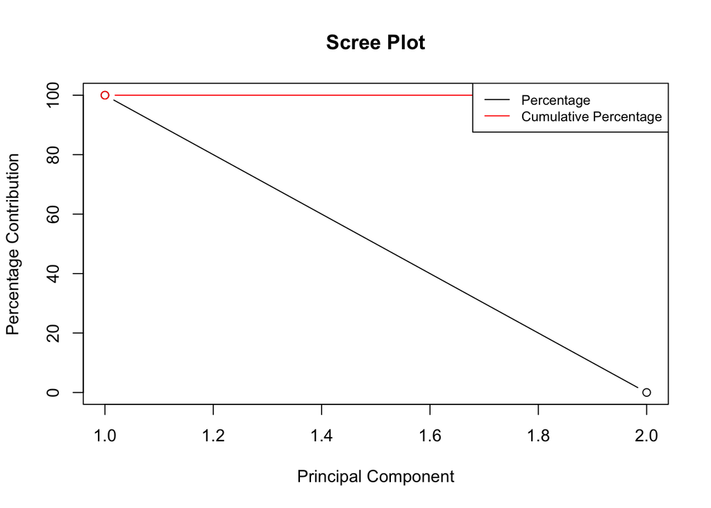

```r
# Finally compute the percentage of contribution from each eigenvector by summing
# the eigenvalues together and dividing each individual eigenvalue by the total. Draw a
# Scree plot to show the differences in contribution from the principal components

percentage_contribution <- eigenvalues / sum(eigenvalues) * 100

# Create a Scree plot
plot(percentage_contribution, type = "b", main = "Scree Plot",
     xlab = "Principal Component", ylab = "Percentage Contribution")

# Add cumulative percentage contribution
cum_percentage <- cumsum(percentage_contribution)
lines(cum_percentage, col = "red", type = "b")

# Add labels
legend("topright", legend = c("Percentage", "Cumulative Percentage"),
       col = c("black", "red"), lty = 1:1, cex = 0.8)
```

# Problem 02

With R, create a PCA plot with PC1 on the X-axis and PC2 on the Y-axis. Construct a Scree plot.

```r
library(dplyr)
iris_test = iris[order(iris$Species),]
rownames(iris_test) = paste(substr(iris_test[,5],1,2),
sample(1:2000, 150, replace = FALSE),sep = "")
set.seed(641)
iris_test = sample_n(iris_test, 20)

iris_test
```

|  | Sepal.Length | Sepal.Width | Petal.Length | Petal.Width | Species |
| --- | --- | --- | --- | --- | --- |
| se408 | 5.1 | 3.8 | 1.9 | 0.4 | setosa |
| ve1717 | 5.6 | 3.0 | 4.1 | 1.3 | versicolor |
| ve850 | 5.5 | 2.6 | 4.4 | 1.2 | versicolor |
| se1631 | 4.7 | 3.2 | 1.6 | 0.2 | setosa |
| ve1865 | 5.8 | 2.7 | 4.1 | 1.0 | versicolor |
| se130 | 5.1 | 3.5 | 1.4 | 0.3 | setosa |
| ve1311 | 6.0 | 3.4 | 4.5 | 1.6 | versicolor |
| ve1672 | 5.7 | 3.0 | 4.2 | 1.2 | versicolor |
| se544 | 5.0 | 3.5 | 1.3 | 0.3 | setosa |
| se543 | 5.7 | 4.4 | 1.5 | 0.4 | setosa |

[output cut: 10 more lines]

```r
iris_matrix <- as.matrix(iris_test[1:20, 1:5])
iris_matrix
```

```
##        Sepal.Length Sepal.Width Petal.Length Petal.Width Species
## se408  "5.1"        "3.8"       "1.9"        "0.4"       "setosa"
## ve1717 "5.6"        "3.0"       "4.1"        "1.3"       "versicolor"
## ve850  "5.5"        "2.6"       "4.4"        "1.2"       "versicolor"
## se1631 "4.7"        "3.2"       "1.6"        "0.2"       "setosa"
## ve1865 "5.8"        "2.7"       "4.1"        "1.0"       "versicolor"
## se130  "5.1"        "3.5"       "1.4"        "0.3"       "setosa"
## ve1311 "6.0"        "3.4"       "4.5"        "1.6"       "versicolor"
## ve1672 "5.7"        "3.0"       "4.2"        "1.2"       "versicolor"
## se544  "5.0"        "3.5"       "1.3"        "0.3"       "setosa"
## se543  "5.7"        "4.4"       "1.5"        "0.4"       "setosa"
## ve1490 "6.1"        "3.0"       "4.6"        "1.4"       "versicolor"
## vi37   "7.7"        "2.6"       "6.9"        "2.3"       "virginica"
## vi1694 "6.7"        "3.1"       "5.6"        "2.4"       "virginica"
## se8    "5.4"        "3.9"       "1.3"        "0.4"       "setosa"
## ve1210 "5.8"        "2.6"       "4.0"        "1.2"       "versicolor"
## vi672  "6.0"        "3.0"       "4.8"        "1.8"       "virginica"
## vi1442 "6.3"        "3.3"       "6.0"        "2.5"       "virginica"
## ve567  "6.6"        "3.0"       "4.4"        "1.4"       "versicolor"
## vi1011 "7.4"        "2.8"       "6.1"        "1.9"       "virginica"
## se1945 "4.9"        "3.1"       "1.5"        "0.1"       "setosa"
```

```r
extract_and_convert_matrix <- function(mat) {
  middle_four <- mat[, 1:4]
  middle_four <- apply(middle_four, 2, function(x) as.numeric(as.character(x)))
  return(middle_four)
}

# Pass the matrix to the function
result_matrix <- extract_and_convert_matrix(iris_matrix)
print(result_matrix)
```

```
##       Sepal.Length Sepal.Width Petal.Length Petal.Width
##  [1,]          5.1         3.8          1.9         0.4
##  [2,]          5.6         3.0          4.1         1.3
##  [3,]          5.5         2.6          4.4         1.2
##  [4,]          4.7         3.2          1.6         0.2
##  [5,]          5.8         2.7          4.1         1.0
##  [6,]          5.1         3.5          1.4         0.3
##  [7,]          6.0         3.4          4.5         1.6
##  [8,]          5.7         3.0          4.2         1.2
##  [9,]          5.0         3.5          1.3         0.3
## [10,]          5.7         4.4          1.5         0.4
## [11,]          6.1         3.0          4.6         1.4
## [12,]          7.7         2.6          6.9         2.3
## [13,]          6.7         3.1          5.6         2.4
## [14,]          5.4         3.9          1.3         0.4
## [15,]          5.8         2.6          4.0         1.2
## [16,]          6.0         3.0          4.8         1.8
## [17,]          6.3         3.3          6.0         2.5
## [18,]          6.6         3.0          4.4         1.4
## [19,]          7.4         2.8          6.1         1.9
## [20,]          4.9         3.1          1.5         0.1
```

```r
pca <- prcomp(t(result_matrix), scale=TRUE)
pca
```

```
## Standard deviations (1, .., p=4):
## [1] 4.123522e+00 1.719234e+00 2.019965e-01 1.053843e-15
##
## Rotation (n x k) = (20 x 4):
##              PC1         PC2         PC3         PC4
##  [1,] -0.2107231 -0.28560380 -0.30817168  0.30313513
##  [2,] -0.2405404  0.06988648 -0.20712872 -0.37113092
##  [3,] -0.2336353  0.15330929 -0.24194794  0.17869170
##  [4,] -0.2158382 -0.26498198 -0.09066822  0.17615669
##  [5,] -0.2396897  0.08832806 -0.04230031  0.01390490
##  [6,] -0.2072234 -0.30157289  0.15893279 -0.09175166
##  [7,] -0.2404977  0.06706676 -0.28186140 -0.02043216
##  [8,] -0.2400592  0.07604282 -0.27239928  0.34056723
##  [9,] -0.2039711 -0.31407180  0.15856709 -0.20743066
## [10,] -0.1956041 -0.34373234 -0.07054998 -0.16625044
## [11,] -0.2377513  0.11403609 -0.10287254 -0.07225620
## [12,] -0.2078194  0.29773955  0.29765901 -0.23870726
## [13,] -0.2236814  0.22206726  0.29292281  0.03524217
## [14,] -0.1982759 -0.33418254  0.18816463 -0.14661853
## [15,] -0.2390500  0.09338199  0.25075613  0.14781019
## [16,] -0.2335009  0.15706580 -0.01524706 -0.23748686
## [17,] -0.2135240  0.27282795 -0.34150167 -0.31549350
## [18,] -0.2399485  0.07416740  0.34166732  0.01790097
## [19,] -0.2224719  0.22989614  0.23313064  0.48856918
## [20,] -0.2178272 -0.25530910  0.11548634  0.09990850
```

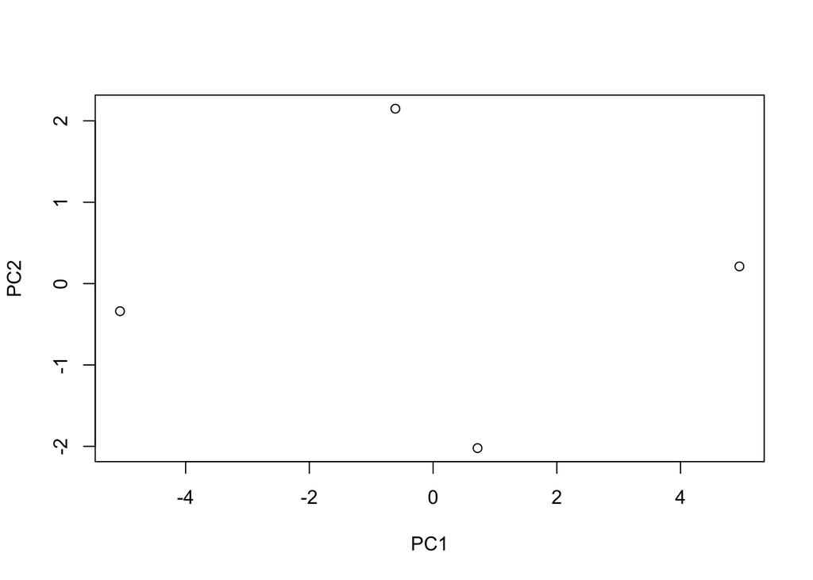

```r
plot(pca$x[,1], pca$x[,2], xlab = "PC1", ylab = "PC2")
```

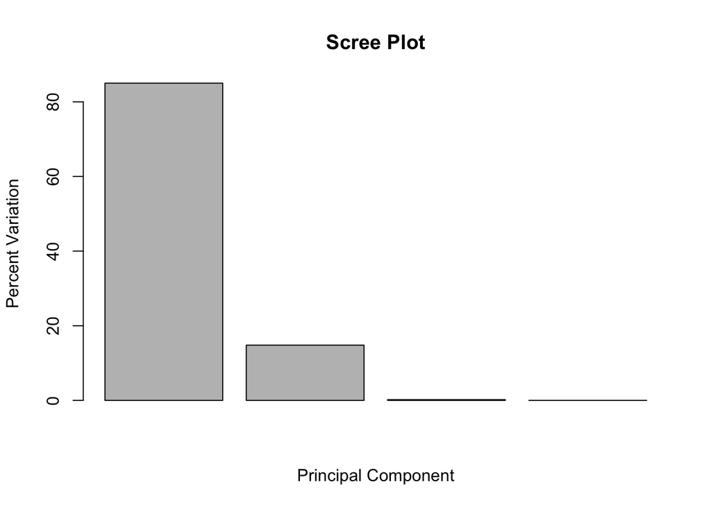

```r
# make a scree plot
pca.var <- pca$sdev^2
pca.var.per <- round(pca.var/sum(pca.var)*100, 1)

barplot(pca.var.per, main="Scree Plot", xlab="Principal Component", ylab="Percent Variation")

library(ggplot2)
```

```r
library(ggthemes)

pca.data <- data.frame(Sample=rownames(pca$x),
                       X=pca$x[,1],
                       Y=pca$x[,2])
pca.data
```

|  | Sample | X | Y |
| --- | --- | --- | --- |
| Sepal.Length | Sepal.Length | -5.0602217 | -0.3391065 |
| Sepal.Width | Sepal.Width | 0.7183045 | -2.0217211 |
| Petal.Length | Petal.Length | -0.6095419 | 2.1494843 |
| Petal.Width | Petal.Width | 4.9514592 | 0.2113433 |

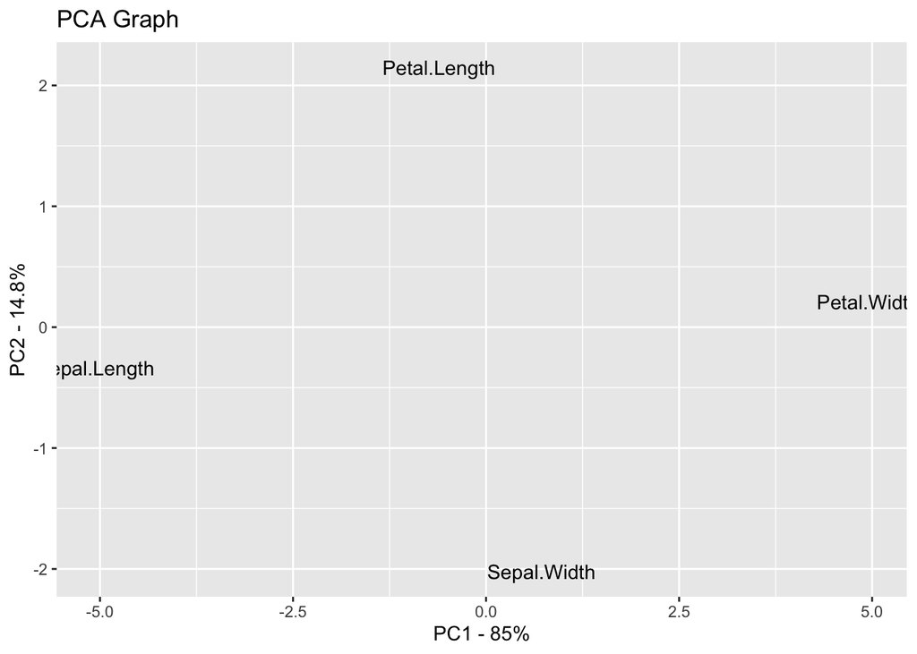

```r
ggplot(data=pca.data, aes(x=X, y=Y, label=Sample)) +
  geom_text() +
  xlab(paste("PC1 - ", pca.var.per[1], "%", sep="")) +
  ylab(paste("PC2 - ", pca.var.per[2], "%", sep="")) +
  ggtitle("PCA Graph")
```